2021204013 문다예 데이터마이닝 선형회귀, 로지스틱회귀 과제

# 1. 일상생활에서 볼 수 있는 Odds 사례를 한 가지 찾아보고 설명하시오.

Odds란 실패할 확률 대비 성공할 확률이다. 우리 일상에서 볼 수 있는 Odds의 사례로는 로또가 있다. 동행복권 기업에서 로또6/45라고 불리는 로또를 판매하고 있다. 로또는 1부터 45까지 숫자 중에 6개의 숫자를 선택하여 티켓에 표기한다. 매주 토요일에 무작위로 6개의 숫자가 선택된다. 로또의 Odds는 각 번호를 맞히는 확률이다. 숫자가 많은 만큼 확률이 상당히 낮다. 로또의 Odds 아래와 같다.

1. 1등(6개의 번호 모두 일치)  
   1/7,509,579
2. 2등 (5개 번호 + 1개 보너스 번호 일치)  
   1/1,083,197
3. 3등 (5개 번호 일치) 1/183,661
4. 4등 (4등 4개 번호 일치)  
   1/8,372
5. 5등 (3개 번호 일치)  
   1/1,397
6. 6등 (2개 번호 일치)  
   1/269

# 2. 선형회귀분석, 로지스틱회귀분석 각 수행

## 2.1 데이터 수집 및 전처리

사용 데이터: https://archive.ics.uci.edu/dataset/437/residential+building+data+set

```python
# 필요한 라이브러리 import

import pandas as pd
from sklearn.model_selection import train_test_split
from sklearn.linear_model import LinearRegression
from sklearn.metrics import mean_squared_error, r2_score
from sklearn.preprocessing import MinMaxScaler, StandardScaler
import matplotlib.pyplot as plt
import seaborn as sns
from scipy import stats
import platform
from matplotlib import font_manager, rc
import statsmodels.api as sm
from statsmodels.stats.outliers_influence import variance_inflation_factor
from sklearn.linear_model import LogisticRegression
from sklearn.metrics import accuracy_score, classification_report, confusion_matrix
import numpy as np


# 그래프 폰트 설정
if platform.system() == 'Windows':
    font_name = font_manager.FontProperties(fname="c:/Windows/Fonts/malgun.ttf").get_name()
    rc('font', family=font_name)
```

```python
# 데이터 파일 불러오기
data = pd.read_excel("./Residential-Building-Data-Set.xlsx")
data.iloc[:, 4:]

# 0행을 컬럼명으로 설정
data.columns = data.iloc[0]

# 0행을 삭제
data = data[1:]

# 4열부터 시작하는 데이터 선택
data = data.iloc[:, 4:]
df = pd.DataFrame(data)
df = df.apply(pd.to_numeric, errors='coerce')
df
```

|  | V-1 | V-2 | V-3 | V-4 | V-5 | V-6 | V-7 | V-8 | V-11 | V-12 | ... | V-22 | V-23 | V-24 | V-25 | V-26 | V-27 | V-28 | V-29 | V-9 | V-10 |
| --- | --- | --- | --- | --- | --- | --- | --- | --- | --- | --- | --- | --- | --- | --- | --- | --- | --- | --- | --- | --- | --- |
| 1 | 1 | 3150.0 | 920.0 | 598.5 | 190 | 1010.84 | 16 | 1200 | 6713.00 | 56.2 | ... | 815.50 | 1755.00 | 8002.0 | 60.74 | 54.26 | 2978.26 | 41407.00 | 601988.1 | 2200 | 410 |
| 2 | 1 | 7600.0 | 1140.0 | 3040.0 | 400 | 963.81 | 23 | 2900 | 3152.00 | 106.0 | ... | 1316.30 | 8364.78 | 8393.0 | 90.95 | 89.79 | 11379.37 | 44835.00 | 929027.1 | 5000 | 1000 |
| 3 | 1 | 4800.0 | 840.0 | 480.0 | 100 | 689.84 | 15 | 630 | 1627.00 | 41.0 | ... | 765.80 | 1755.00 | 4930.0 | 38.70 | 32.04 | 1653.06 | 37933.00 | 377828.6 | 1200 | 170 |
| 4 | 1 | 685.0 | 202.0 | 13.7 | 20 | 459.54 | 4 | 140 | 2580.93 | 12.1 | ... | 152.25 | 1442.31 | 1456.0 | 9.73 | 8.34 | 686.16 | 8194.00 | 122031.7 | 165 | 30 |
| 5 | 1 | 3000.0 | 800.0 | 1230.0 | 410 | 631.91 | 13 | 5000 | 6790.00 | 203.8 | ... | 2244.10 | 9231.76 | 9286.0 | 136.60 | 140.20 | 9821.00 | 48260.00 | 1734973.5 | 5500 | 700 |
| ... | ... | ... | ... | ... | ... | ... | ... | ... | ... | ... | ... | ... | ... | ... | ... | ... | ... | ... | ... | ... | ... |
| 368 | 20 | 1350.0 | 350.0 | 108.0 | 80 | 251.37 | 9 | 830 | 2700.00 | 103.0 | ... | 1176.50 | 8343.60 | 8382.0 | 87.27 | 85.56 | 10555.47 | 33626.25 | 865878.9 | 1100 | 150 |
| 369 | 20 | 600.0 | 150.0 | 36.0 | 60 | 299.55 | 6 | 570 | 6713.00 | 59.1 | ... | 815.50 | 1755.00 | 8013.0 | 62.78 | 56.45 | 3387.72 | 10646.75 | 606524.2 | 740 | 80 |
| 370 | 20 | 1900.0 | 430.0 | 285.0 | 150 | 364.41 | 7 | 640 | 2918.00 | 120.2 | ... | 1584.30 | 8776.71 | 8799.0 | 101.00 | 101.89 | 13571.80 | 34474.50 | 1067772.0 | 860 | 220 |
| 371 | 20 | 510.0 | 160.0 | 30.6 | 60 | 245.28 | 9 | 790 | 2247.00 | 76.9 | ... | 909.20 | 7930.66 | 8004.0 | 73.57 | 69.26 | 4756.68 | 21855.00 | 669640.3 | 1100 | 110 |
| 372 | 20 | 890.0 | 230.0 | 35.6 | 40 | 237.03 | 6 | 350 | 7196.00 | 51.3 | ... | 764.50 | 1755.00 | 8420.0 | 54.62 | 44.79 | 2206.19 | 40234.00 | 629797.2 | 460 | 50 |

372 rows × 105 columns

#### 변수 설명

V-1 우편번호에 따라 정의된 지역성  
V-2 건물 총면적  
V-3 총면적  
V-4 사업초기가격기준 총예비추정공사비  
V-5 프로젝트 초기 가격에 따른 예비 예상 공사비  
V-6 선정된 기준연도의 사업초기 가격을 기준으로 한 등가예비추정공사비  
V-7 공사기간  
V-8 프로젝트 초기의 m2당 단가  
V-9 실제판매가격(출력)  
V-10 실제 공사비(출력)  
V-11 건축허가서 발급건수  
V-12 사전 선정된 기준연도의 BSI(Building Services Index)  
V-13 기준연도 건자재 도매가격지수(WPI)  
V-14 시·군 건축허가증 연면적  
V-15 누적유동성  
V-16 신축건물에 대한 민간부문의 투자  
V-17 기준연도 지가지수  
V-18 은행의 시간 분해능 대출 건수  
V-19 은행의 시간결의 대출금액  
V-20 시간결의 대출이자율  
V-21 민간부문별 건축물 공사비 평균  
V-22 건설 초기 민간부문별 건축물 공사비 평균  
V-23 달러에 대한 공식 환율  
V-24 달러에 대한 비공인(스트리트 마켓) 환율  
V-25 기준연도 소비자물가지수(CPI)  
V-26 기준연도의 주택, 수도, 연료 및 전력 CPI  
V-27 주식시장지수  
V-28 도시의 인구  
V-29 온스당 금값

```python
# 종속 변수와 독립 변수
# 실제 판매 가격 추이를 보기 위해 V-9를 y로 지정하였다
# 데이터에서 독립 변수 선택

X = data[['V-2', 'V-3', 'V-4', 'V-5', 'V-6', 'V-7', 'V-8', 'V-10',
          'V-11', 'V-12', 'V-13', 'V-14', 'V-15', 'V-16', 'V-17', 'V-18', 'V-19', 'V-20',
          'V-21', 'V-22', 'V-23', 'V-24', 'V-25', 'V-26', 'V-27', 'V-28', 'V-29']]
y = data['V-9']

X = X.apply(pd.to_numeric, errors='coerce')
y = y.apply(pd.to_numeric, errors='coerce')

X_train, X_temp, y_train, y_temp = train_test_split(X, y, test_size=0.3, random_state=42)
X_val, X_test, y_val, y_test = train_test_split(X_temp, y_temp, test_size=0.67, random_state=42)



print(f"학습 데이터: {X_train.shape}")
print(f"검증 데이터: {X_val.shape}")
print(f"테스트 데이터: {X_test.shape}")
```

```
학습 데이터: (260, 103)
검증 데이터: (36, 103)
테스트 데이터: (76, 103)
```

## 2.2 탐색적 데이터 분석 - 데이터 내재적인 특징 가시화

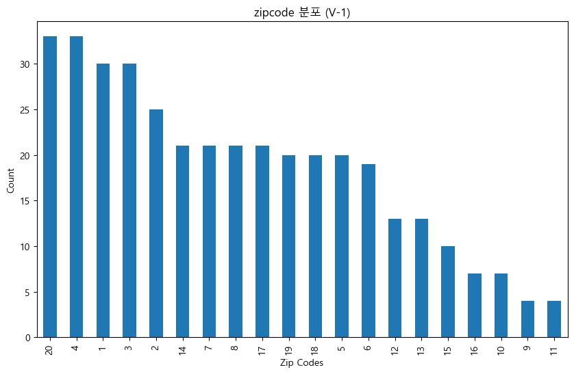

```python
# V-1 zip 코드 분포
zip_counts = data['V-1'].value_counts()

# Bar plot
plt.figure(figsize=(10, 6))
zip_counts.plot(kind = 'bar')
plt.title('zipcode 분포 (V-1)')
plt.xlabel('Zip Codes')
plt.ylabel('Count')
plt.show()
```

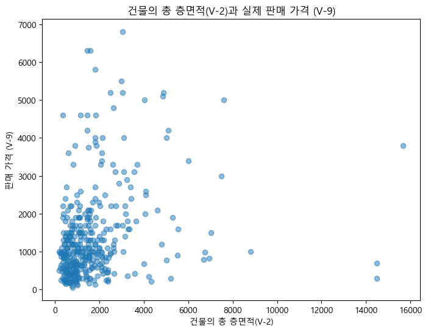

```python
# 건물의 총 층면적과 판매가격간의 관계 파악
# Scatter plot

plt.figure(figsize=(8, 6))
plt.scatter(data['V-2'], data['V-9'], alpha=0.5)
plt.title('건물의 총 층면적(V-2)과 실제 판매 가격 (V-9)')
plt.xlabel('건물의 총 층면적(V-2)')
plt.ylabel('판매 가격 (V-9)')
plt.show()
```

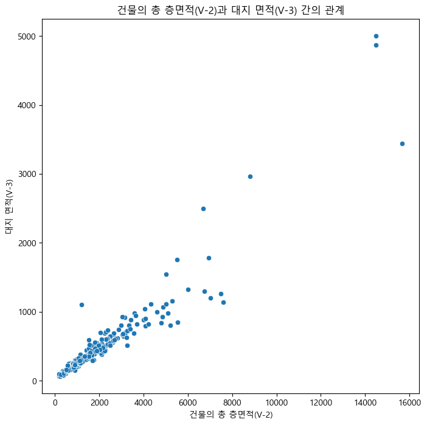

```python
# 건물의 총 층면적(V-2)과 대지 면적(V-3) 간의 관계 파악
# Scatter plot

plt.figure(figsize=(8, 8))
sns.scatterplot(x = 'V-2', y = 'V-3', data = df)
plt.title('건물의 총 층면적(V-2)과 대지 면적(V-3) 간의 관계')
plt.xlabel('건물의 총 층면적(V-2)')
plt.ylabel('대지 면적(V-3)')
plt.show()
```

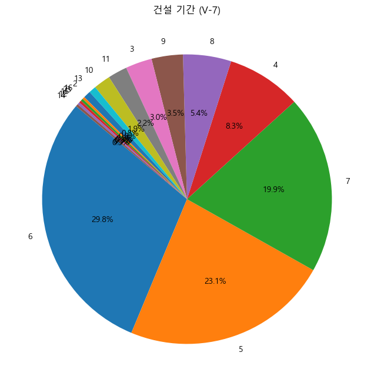

```python
# 건설 기간(V-7) 분포
duration_counts = data['V-7'].value_counts()

# Pie chart
plt.figure(figsize=(8, 8))
plt.pie(duration_counts, labels=duration_counts.index, autopct='%1.1f%%', startangle=140)
plt.title('건설 기간 (V-7)')
plt.show()
```

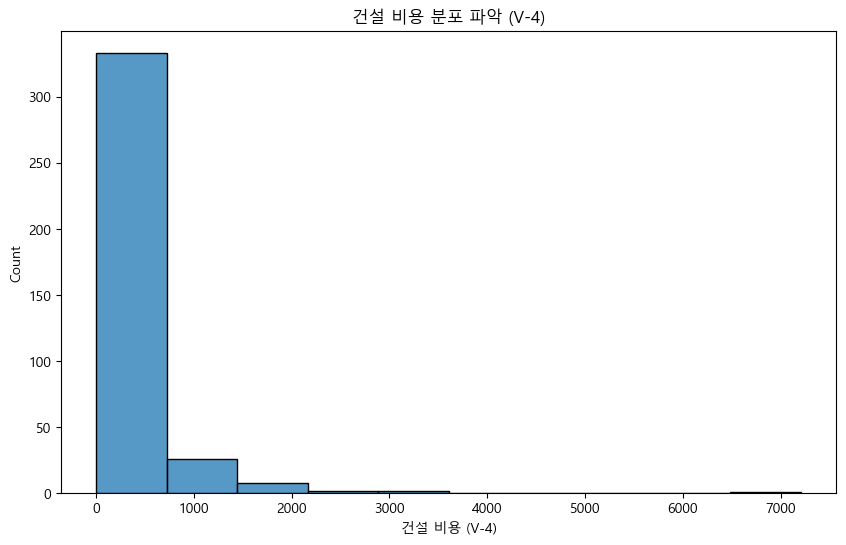

```python
# 건설 비용 분포 파악
# Histogram

plt.figure(figsize=(10, 6))
sns.histplot(df['V-4'], bins=10)
plt.title('건설 비용 분포 파악 (V-4)')
plt.xlabel('건설 비용 (V-4)')
plt.show()
```

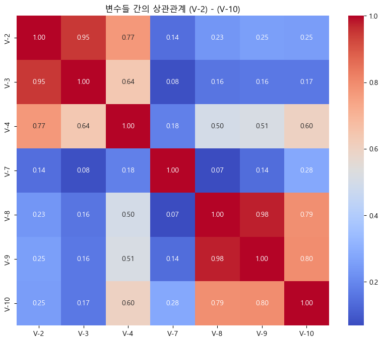

```python
# 건물의 총 층면적, 대지 면적, 건설 예상 비용, 건설 기간,
# 프로젝트 시작 시 단위당 가격, 실제 판매 가격, 실제 건설 비용 간의 상관관계

# 선택한 변수들을 데이터프레임에서 추출
selected_vars = df[['V-2', 'V-3', 'V-4', 'V-7', 'V-8', 'V-9', 'V-10']]

# 상관 히트맵 생성
plt.figure(figsize = (10, 8))
sns.heatmap(selected_vars.corr(), annot = True, cmap = 'coolwarm', fmt = '.2f')
plt.title('변수들 간의 상관관계 (V-2) - (V-10)')
plt.xlabel('')
plt.ylabel('')
plt.show()
```

## 2.2 학습모델 구축

```python
print(X_train)
```

```
0       V-2     V-3     V-4  V-5     V-6  V-7   V-8  V-10    V-11    V-11  \
197  1540.0   340.0   154.0  100  592.57    7   710   140  7196.0  5275.0
20   5020.0  1110.0  1706.8  340  853.01    5  3300   450  3052.0  2918.0
357  1120.0   290.0   190.4  170  306.91    5  1600   240  5606.0  4079.0
80   2030.0   450.0   365.4  180  565.58    6  1800   260  2700.0  3561.0
168  7010.0  1200.0  1472.1  210  718.07    7  1200   300  3678.0  2734.0
..      ...     ...     ...  ...     ...  ...   ...   ...     ...     ...
72   3240.0   630.0   680.4  210  715.52    7  2300   290  3157.0  3678.0
107   390.0   100.0    62.4  160  547.10    8  1000   220  3678.0  2734.0
271   750.0   200.0    45.0   60  423.07    6   360    80  3213.0  2272.0
349   560.0   220.0    22.4   40  319.47    3   350    50  2374.0  2693.0
103  1430.0   440.0    57.2   40  772.31    4   280   120  3321.0  2898.0

0    ...     V-28      V-28      V-28      V-28      V-28       V-29  \
197  ...  41407.0  31055.25  20703.50  10351.75  40234.00   601988.1
```

[output cut: 25 more lines]

```python
# X_train, y_train을 사용하여 OLS 모델을 생성
# X_train = sm.add_constant(X_train)  # 상수항을 추가
model = sm.OLS(y_train, X_train)
results = model.fit()

# 회귀분석 결과 출력
print(results.summary())

# MSE 출력
mse_model = results.mse_model
print('MSE:', mse_model)

# MAE 출력
from sklearn.metrics import mean_absolute_error

predictions = results.predict(X_train)
mae_model = mean_absolute_error(y_train, predictions)
print('MAE:', mae_model)
```

```
                            OLS Regression Results
==============================================================================
Dep. Variable:                    V-9   R-squared:                       0.989
Model:                            OLS   Adj. R-squared:                  0.985
Method:                 Least Squares   F-statistic:                     234.6
Date:                Tue, 14 Nov 2023   Prob (F-statistic):          3.38e-152
Time:                        17:02:58   Log-Likelihood:                -1603.9
No. Observations:                 260   AIC:                             3356.
Df Residuals:                     186   BIC:                             3619.
Df Model:                          73
Covariance Type:            nonrobust
==============================================================================
                 coef    std err          t      P>|t|      [0.025      0.975]
------------------------------------------------------------------------------
V-2            0.0604      0.027      2.235      0.027       0.007       0.114
V-3           -0.2088      0.078     -2.665      0.008      -0.363      -0.054
V-4            0.0216      0.067      0.324      0.746      -0.110       0.153
V-5           -4.0696      0.682     -5.966      0.000      -5.415      -2.724
V-6            0.2374      0.070      3.401      0.001       0.100       0.375
V-7            2.8061      7.680      0.365      0.715     -12.344      17.957
V-8            1.2264      0.019     65.453      0.000       1.189       1.263
V-10           2.0993      0.401      5.231      0.000       1.308       2.891
V-11           0.1129      0.096      1.172      0.243      -0.077       0.303
V-11          -0.0701      0.121     -0.578      0.564      -0.309       0.169
V-11          -0.0635      0.070     -0.904      0.367      -0.202       0.075
V-11           0.0771      0.089      0.865      0.388      -0.099       0.253
V-11          -0.0162      0.078     -0.208      0.836      -0.170       0.137
V-12          -0.0840      5.151     -0.016      0.987     -10.246      10.078
V-12          12.3865      5.961      2.078      0.039       0.627      24.146
V-12          18.4778      9.976      1.852      0.066      -1.203      38.158
V-12           1.5893      4.942      0.322      0.748      -8.161      11.340
V-12           1.5641      6.377      0.245      0.807     -11.016      14.144
V-13          11.2044     14.815      0.756      0.450     -18.023      40.432
V-13           7.9311     11.214      0.707      0.480     -14.192      30.055
V-13           0.1457      7.715      0.019      0.985     -15.074      15.365
V-13          -0.6776      8.283     -0.082      0.935     -17.019      15.664
V-13         -17.7871     10.634     -1.673      0.096     -38.766       3.192
V-14           3.6176      3.112      1.162      0.247      -2.522       9.757
V-14          -0.5561      1.556     -0.357      0.721      -3.626       2.514
V-14          -1.2159      4.082     -0.298      0.766      -9.269       6.838
```

[output cut: 75 more lines]

```
V-29           0.0044      0.003      1.533      0.127      -0.001       0.010
V-29          -0.0033      0.002     -1.325      0.187      -0.008       0.002
==============================================================================
Omnibus:                       99.103   Durbin-Watson:                   2.023
Prob(Omnibus):                  0.000   Jarque-Bera (JB):             2850.227
Skew:                          -0.839   Prob(JB):                         0.00
Kurtosis:                      19.133   Cond. No.                     1.28e+16
==============================================================================

Notes:
[1] Standard Errors assume that the covariance matrix of the errors is correctly specified.
[2] The smallest eigenvalue is 1.33e-17. This might indicate that there are
strong multicollinearity problems or that the design matrix is singular.
MSE: 4378001.063562072
MAE: 62.47482151688615
```

MAE는 예측값과 실제값 간의 절대적인 오차를 나타내며, 값이 작을수록 모델의 예측이 정확하다고 할 수 있다.  
MSE는 에러의 제곱 평균으로, 값이 작을수록 모델의 예측이 정확하다고 할 수 있다.

## 2.3 선형회귀모델 진단

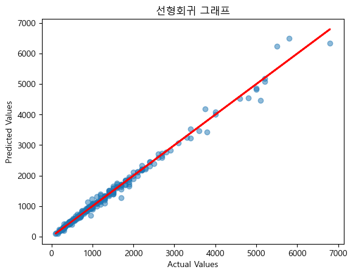

```python
predicted_values = results.predict(X_train)
actual_values = y_train

# 산점도 그리기
plt.scatter(actual_values, predicted_values, alpha=0.5)

# 회귀선 추가
plt.plot(actual_values, actual_values, color='red', linewidth=2)

# 그래프 제목과 라벨 설정
plt.title('선형회귀 그래프')
plt.xlabel('Actual Values')
plt.ylabel('Predicted Values')

# 그래프 출력
plt.show()
```

### 선형회귀 모형 진단

```python
X_train
```

|  | V-2 | V-3 | V-4 | V-5 | V-6 | V-7 | V-8 | V-10 | V-11 | V-11 | ... | V-28 | V-28 | V-28 | V-28 | V-28 | V-29 | V-29 | V-29 | V-29 | V-29 |
| --- | --- | --- | --- | --- | --- | --- | --- | --- | --- | --- | --- | --- | --- | --- | --- | --- | --- | --- | --- | --- | --- |
| 197 | 1540.0 | 340.0 | 154.0 | 100 | 592.57 | 7 | 710 | 140 | 7196.0 | 5275.0 | ... | 41407.0 | 31055.25 | 20703.50 | 10351.75 | 40234.00 | 601988.1 | 588020.5 | 605688.7 | 626960.3 | 629797.2 |
| 20 | 5020.0 | 1110.0 | 1706.8 | 340 | 853.01 | 5 | 3300 | 450 | 3052.0 | 2918.0 | ... | 47096.0 | 35322.00 | 23548.00 | 11774.00 | 45966.00 | 1391757.1 | 1181856.2 | 1167697.4 | 1181572.6 | 1188995.8 |
| 357 | 1120.0 | 290.0 | 190.4 | 170 | 306.91 | 5 | 1600 | 240 | 5606.0 | 4079.0 | ... | 48260.0 | 36195.00 | 24130.00 | 12065.00 | 47096.00 | 1734973.5 | 1654038.4 | 1660444.0 | 1673301.4 | 1391757.1 |
| 80 | 2030.0 | 450.0 | 365.4 | 180 | 565.58 | 6 | 1800 | 260 | 2700.0 | 3561.0 | ... | 34474.5 | 22983.00 | 11491.50 | 44835.00 | 33626.25 | 1067772.0 | 973523.7 | 954628.6 | 929027.1 | 865878.9 |
| 168 | 7010.0 | 1200.0 | 1472.1 | 210 | 718.07 | 7 | 1200 | 300 | 3678.0 | 2734.0 | ... | 44835.0 | 33626.25 | 22417.50 | 11208.75 | 43710.00 | 929027.1 | 865878.9 | 833494.6 | 817526.9 | 788018.3 |
| ... | ... | ... | ... | ... | ... | ... | ... | ... | ... | ... | ... | ... | ... | ... | ... | ... | ... | ... | ... | ... | ... |
| 72 | 3240.0 | 630.0 | 680.4 | 210 | 715.52 | 7 | 2300 | 290 | 3157.0 | 3678.0 | ... | 11491.5 | 44835.00 | 33626.25 | 22417.50 | 11208.75 | 954628.6 | 929027.1 | 865878.9 | 833494.6 | 817526.9 |
| 107 | 390.0 | 100.0 | 62.4 | 160 | 547.10 | 8 | 1000 | 220 | 3678.0 | 2734.0 | ... | 44835.0 | 33626.25 | 22417.50 | 11208.75 | 43710.00 | 929027.1 | 865878.9 | 833494.6 | 817526.9 | 788018.3 |
| 271 | 750.0 | 200.0 | 45.0 | 60 | 423.07 | 6 | 360 | 80 | 3213.0 | 2272.0 | ... | 20117.0 | 10058.50 | 39066.00 | 29299.50 | 19533.00 | 566492.3 | 540680.6 | 524764.8 | 466212.2 | 409677.9 |
| 349 | 560.0 | 220.0 | 22.4 | 40 | 319.47 | 3 | 350 | 50 | 2374.0 | 2693.0 | ... | 9766.5 | 37933.00 | 28449.75 | 18966.50 | 9483.25 | 403875.0 | 377828.6 | 377633.3 | 390388.5 | 408321.5 |
| 103 | 1430.0 | 440.0 | 57.2 | 40 | 772.31 | 4 | 280 | 120 | 3321.0 | 2898.0 | ... | 36818.0 | 27613.50 | 18409.00 | 9204.50 | 35763.00 | 415431.1 | 413834.5 | 402158.1 | 420359.6 | 420700.5 |

260 rows × 103 columns

```python
# VIF 계산
vif_data = pd.DataFrame()
vif_data["Variable"] = X_train.columns
vif_data["VIF"] = [variance_inflation_factor(X_train.values, i) for i in range(X_train.shape[1])]

# VIF가 10보다 큰 변수 찾기
high_vif_vars = vif_data[vif_data["VIF"] > 10]["Variable"].tolist()

# 필요하다면 해당 변수를 X_train에서 제거
X_train_reduced_vif = X_train.drop(columns=high_vif_vars)

# VIF가 10보다 큰 변수 제거 후의 데이터프레임
print("Reduced X_train after VIF:")
print(X_train_reduced_vif.head())

# VIF 값 출력
print("\nVIF values after reduction:")
print(vif_data[vif_data["Variable"].isin(X_train_reduced_vif.columns)])
```

```
Reduced X_train after VIF:
0       V-6  V-7   V-8
197  592.57    7   710
20   853.01    5  3300
357  306.91    5  1600
80   565.58    6  1800
168  718.07    7  1200

VIF values after reduction:
  Variable       VIF
4      V-6  6.114829
5      V-7  3.613411
6      V-8  4.215355
```

```python
# VIF가 10보다 큰 변수 제거 후의 데이터프레임

print("Reduced X_train after VIF:")
X_train_reduced_vif
```

```
Reduced X_train after VIF:
```

|  | V-6 | V-7 | V-8 |
| --- | --- | --- | --- |
| 197 | 592.57 | 7 | 710 |
| 20 | 853.01 | 5 | 3300 |
| 357 | 306.91 | 5 | 1600 |
| 80 | 565.58 | 6 | 1800 |
| 168 | 718.07 | 7 | 1200 |
| ... | ... | ... | ... |
| 72 | 715.52 | 7 | 2300 |
| 107 | 547.10 | 8 | 1000 |
| 271 | 423.07 | 6 | 360 |
| 349 | 319.47 | 3 | 350 |
| 103 | 772.31 | 4 | 280 |

260 rows × 3 columns

```python
X = data[['V-6', 'V-7', 'V-8']]
y = data['V-9']

X = X.apply(pd.to_numeric, errors='coerce')
y = y.apply(pd.to_numeric, errors='coerce')

# 학습 데이터와 테스트 데이터로 분할
X_train, X_test, y_train, y_test = train_test_split(X, y, test_size=0.2, random_state=42)
X_val, X_test, y_val, y_test = train_test_split(X_temp, y_temp, test_size = 0.67, random_state=42)


print(f"학습 데이터: {X_train.shape}")
print(f"검증 데이터: {X_val.shape}")
print(f"데스트 데이터: {X_test.shape}")
```

```
학습 데이터: (297, 3)
검증 데이터: (36, 103)
데스트 데이터: (76, 103)
```

```python
# X_train, y_train을 사용하여 OLS 모델을 생성
# X_train = sm.add_constant(X_train)  # 상수항을 추가
model = sm.OLS(y_train, X_train)
results = model.fit()

# 회귀분석 결과 출력
print(results.summary())

# MSE 출력
mse_model = results.mse_model
print('MSE:', mse_model)
```

```
                                 OLS Regression Results
=======================================================================================
Dep. Variable:                    V-9   R-squared (uncentered):                   0.980
Model:                            OLS   Adj. R-squared (uncentered):              0.980
Method:                 Least Squares   F-statistic:                              4878.
Date:                Tue, 14 Nov 2023   Prob (F-statistic):                   2.55e-250
Time:                        17:03:37   Log-Likelihood:                         -2058.7
No. Observations:                 297   AIC:                                      4123.
Df Residuals:                     294   BIC:                                      4135.
Df Model:                           3
Covariance Type:            nonrobust
==============================================================================
                 coef    std err          t      P>|t|      [0.025      0.975]
------------------------------------------------------------------------------
V-6            0.0216      0.047      0.457      0.648      -0.071       0.115
V-7           21.1717      4.541      4.663      0.000      12.236      30.108
V-8            1.1406      0.015     77.525      0.000       1.112       1.170
==============================================================================
Omnibus:                      117.318   Durbin-Watson:                   2.002
Prob(Omnibus):                  0.000   Jarque-Bera (JB):             3154.484
Skew:                          -0.971   Prob(JB):                         0.00
Kurtosis:                      18.847   Cond. No.                         473.
==============================================================================

Notes:
[1] R² is computed without centering (uncentered) since the model does not contain a constant.
[2] Standard Errors assume that the covariance matrix of the errors is correctly specified.
MSE: 302652539.03420657
```

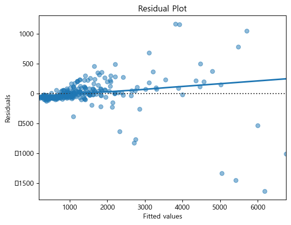

```python
# Residuals 계산
residuals = results.resid

# Residual Plot
sns.residplot(x = results.fittedvalues, y = residuals, lowess = True, scatter_kws={'alpha': 0.5})
plt.title('Residual Plot')
plt.xlabel('Fitted values')
plt.ylabel('Residuals')
plt.show()
```

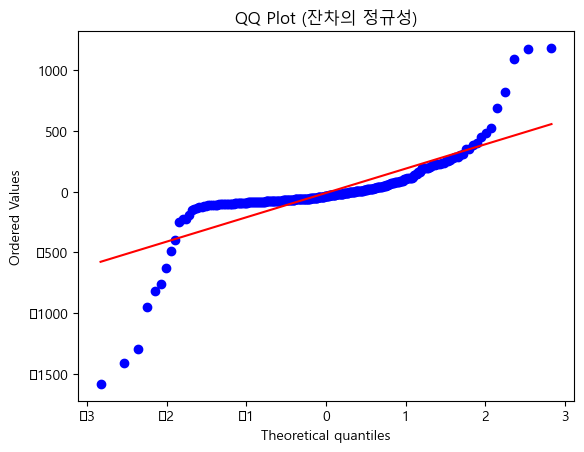

```python
# QQ Plot
stats.probplot(residuals, dist="norm", plot=plt)
plt.title('QQ Plot (잔차의 정규성)')
plt.show()
```

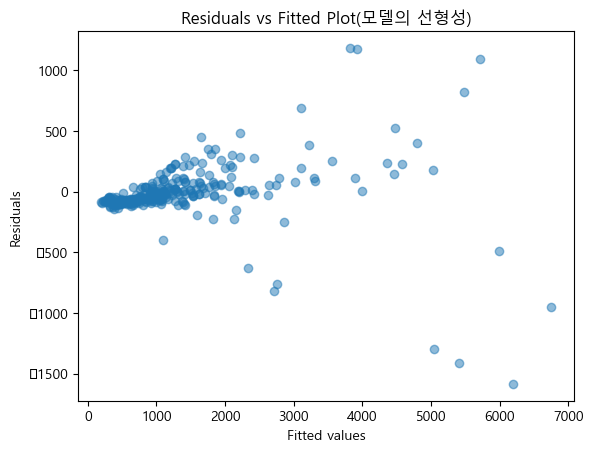

```python
# Residuals vs Fitted Plot
plt.scatter(results.fittedvalues, residuals, alpha=0.5)
plt.title('Residuals vs Fitted Plot(모델의 선형성)')
plt.xlabel('Fitted values')
plt.ylabel('Residuals')
plt.show()
```

Residuals vs Fitted Plot은 적합된 값에 대한 잔차의 산점도를 표시한다.  
Residuals vs Fitted Plot에서 3000 이전까지는 잔차가 0에 모여 있다는 것을 볼 수 있다.  
이는 회귀 모델이 데이터에 대해 적절하게 적합되어 예측 오차가 크게 발생하지 않는다는 것을 나타낸다.  
3000 이후부터는 잔차가 무작위로 퍼지고 있는 모습을 보아, 모델이 데이터에 적합하지 않거나 모델에 추가적인 설명변수가 필요하다고 볼 수 있다.</br>

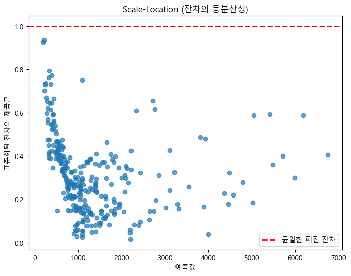

```python
predicted_values = results.predict(X_train)

# 표준화된 잔차 계산
sqrt_abs_resid = np.sqrt(np.abs(residuals / results.model.endog))

# Scale-Location 그래프 생성
plt.figure(figsize=(8, 6))
plt.scatter(predicted_values, sqrt_abs_resid, alpha=0.7)
plt.title('Scale-Location (잔차의 등분산성)')
plt.xlabel('예측값')
plt.ylabel('표준화된 잔차의 제곱근')
plt.axhline(y=1.0, color='r', linestyle='--', linewidth=2, label='균일한 퍼진 잔차')
plt.legend()
plt.show()
```

Scale-Location 그래프는 수평선 주위에 잔차가 랜덤하게 흩어져야 등분산성 가정을 따른다고 볼 수 있다.  
하지만 그래프에서 잔차가 0에서 1000 사이에 몰려 있다.  
모델이 특정 범위에서 예측의 정확성이 떨어진다는 것을 나타낼 수 있다.  
특정 범위에서는 예측이 부정확하거나 다른 패턴을 따른다는 의미이다.

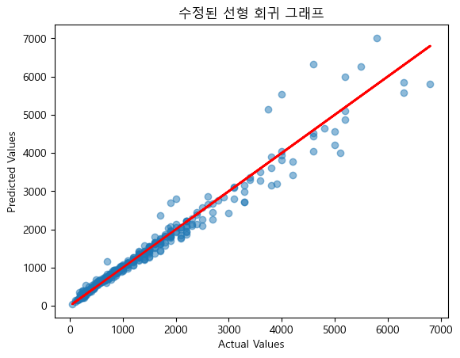

```python
X = sm.add_constant(X)

# OLS 모델 피팅
model = sm.OLS(y, X)
results = model.fit()

# 예측값 계산
predicted_values = results.predict(X)

# 산점도 그리기
plt.scatter(y, predicted_values, alpha=0.5)

# 회귀선 추가
plt.plot(y, y, color='red', linewidth=2)

# 그래프 제목과 라벨 설정
plt.title('수정된 선형 회귀 그래프')
plt.xlabel('Actual Values')
plt.ylabel('Predicted Values')

# 그래프 출력
plt.show()
```

```python
# 이진 분류로 변환 (예: 0보다 크면 1, 그렇지 않으면 0)
y_train_binary = (y_train > y_train.mean()).astype(int)

# 로지스틱 회귀 모델 생성
model = sm.Logit(y_train_binary, X_train)

# 모델 학습
results = model.fit()

# 결과 출력
print(results.summary())
```

```
Optimization terminated successfully.
         Current function value: 0.285055
         Iterations 8
                           Logit Regression Results
==============================================================================
Dep. Variable:                    V-9   No. Observations:                  297
Model:                          Logit   Df Residuals:                      294
Method:                           MLE   Df Model:                            2
Date:                Tue, 14 Nov 2023   Pseudo R-squ.:                  0.5554
Time:                        17:03:54   Log-Likelihood:                -84.661
converged:                       True   LL-Null:                       -190.40
Covariance Type:            nonrobust   LLR p-value:                 1.197e-46
==============================================================================
                 coef    std err          z      P>|z|      [0.025      0.975]
------------------------------------------------------------------------------
V-6           -0.0026      0.001     -2.551      0.011      -0.005      -0.001
V-7           -0.7114      0.113     -6.272      0.000      -0.934      -0.489
V-8            0.0056      0.001      7.631      0.000       0.004       0.007
==============================================================================
```

```python
from sklearn.metrics import confusion_matrix, classification_report

# 로지스틱 회귀 모델의 예측값 가져오기
y_pred_binary = results.predict(X_train) > 0.5

# 실제값을 0 또는 1로 변환
y_train_binary_actual = (y_train > y_train.mean()).astype(int)

# Confusion Matrix 계산
cm = confusion_matrix(y_train_binary_actual, y_pred_binary)
print("Confusion Matrix:")
print(cm)

# Classification Report 출력 (Recall, Precision, F1 Score 포함)
print("Classification Report:")
print(classification_report(y_train_binary_actual, y_pred_binary))
```

```
Confusion Matrix:
[[176  20]
 [ 19  82]]
Classification Report:
              precision    recall  f1-score   support

           0       0.90      0.90      0.90       196
           1       0.80      0.81      0.81       101

    accuracy                           0.87       297
   macro avg       0.85      0.85      0.85       297
weighted avg       0.87      0.87      0.87       297
```

## 2.5 회귀와 분류모델에 대해서 선형성(linear model)은 유지한 체, shrinkage models를 활용해 예측 정확도를 향상하시오

```python
import numpy as np
import pandas as pd
from sklearn.model_selection import train_test_split
from sklearn.linear_model import Lasso, Ridge, ElasticNet
from sklearn.metrics import mean_squared_error, r2_score, mean_absolute_error


# 데이터를 학습용과 테스트용으로 나누기
X_train, X_test, y_train, y_test = train_test_split(X, y, test_size=0.2, random_state=42)

# Lasso 회귀
lasso = Lasso(alpha=0.01)
lasso.fit(X_train, y_train)
lasso_pred = lasso.predict(X_test)

# Ridge 회귀
ridge = Ridge(alpha=0.01)
ridge.fit(X_train, y_train)
ridge_pred = ridge.predict(X_test)

# Elastic Net 회귀
elastic_net = ElasticNet(alpha=0.01, l1_ratio=0.5)
elastic_net.fit(X_train, y_train)
elastic_net_pred = elastic_net.predict(X_test)

# 각 모델 평가
def evaluate_model(y_true, y_pred, model_name):
    mse = mean_squared_error(y_true, y_pred)
    mae = mean_absolute_error(y_true, y_pred)
    r2 = r2_score(y_true, y_pred)
    print(f"{model_name} MSE: {mse}")
    print(f"{model_name} MAE: {mae}")
    print(f"{model_name} R-squared: {r2}")
    print("-" * 30)

# 각 모델 평가
evaluate_model(y_test, lasso_pred, "Lasso")
evaluate_model(y_test, ridge_pred, "Ridge")
evaluate_model(y_test, elastic_net_pred, "Elastic Net")
```

```
Lasso MSE: 63434.9712333516
Lasso MAE: 142.01446473131026
Lasso R-squared: 0.9654580376162214
------------------------------
Ridge MSE: 63434.525640027845
Ridge MAE: 142.01325039652005
Ridge R-squared: 0.9654582802531696
------------------------------
Elastic Net MSE: 63443.874154699246
Elastic Net MAE: 142.03867338589612
Elastic Net R-squared: 0.9654531897481083
------------------------------
```

R-squared 값은 모든 모델에서 0.96의 수치로 매우 높게 나타났다.  
MAE는 142로 모든 모델에서 비슷한 수준으로 나타나고 있다. MSE는 63434로 MAE와 마찬가지로 모든 모델에서 비슷한 수준으로 나타나고 있다.

Lasso, Ridge, Elastic Net 간에 큰 차이가 없는 것으로 보인다.

#### 장단점 비교

1. Lasso

장점:  
불필요한 특정 변수를 제거하고 모델을 간결하게 만들 수 있다.  
특정 변수의 계수를 0으로 만들어 해당 변수를 제외한 특징들만 고려한다.

단점:  
계수를 0으로 만들어버리기 때문에 변수 간의 상관관계가 있을 때 하나의 변수만 선택하고 나머지는 0으로 만들 수 있다.

1. Ridge:

장점:  
다중공선성 문제에 대처할 수 있다. 변수들의 계수를 0에 가깝게 만들어 주지만, 완전히 0으로 만들지는 않는다.

단점:  
일부 변수들의 계수가 0이 되지 않아 해석이 어려울 수 있다.

1. Elastic Net:

장점:  
L1과 L2 규제를 모두 사용하여 Lasso와 Ridge의 장점을 모두 취할 수 있다.  
Ridge의 다중공선성 제어 능력과 Lasso의 변수 선택 능력을 모두 가지고 있다.  
데이터셋이 크고 변수가 많을 때 유용하다.

단점:  
두 개의 파라미터를 튜닝해야 하므로 조절이 필요하다. 두 가지 규제를 모두 사용하므로, 모델이 다소 복잡해질 수 있다.

Lasso: 변수 선택이 중요하거나 특정 변수의 영향을 알고 싶을 때 사용하면 적합하다.  
Ridge: 다중공선성이 있거나 변수 간의 상관관계가 높을 때 사용하면 적합하다.  
Elastic Net: 변수 선택과 다중공선성 제어가 모두 필요할 때 적합하다.